# Digital Signal Processing - Lecture 1

Linear Time-Invariant (LTI) systems

Ewout Bergsma

Hanze University of Applied Sciences

# Overview

## About the course

- 6 lectures
- Emphasis on applying DSP using Python
- 50% of Introduction to Smart Systems Engineering

## Some books

**Digital Signal Processing First**

James H. McClellan, Ronald W. Schafer, Mark A. Yoder

ISBN 9781292113869

Source: https://api.pageplace.de/preview/DT0400.9781292113876_A27168748/preview-9781292113876_A27168748.pdf

**Think DSP**

Allen B. Downey

ISBN 9781491938515

Source: https://greenteapress.com/thinkdsp/thinkdsp.pdf

**Engineering Mathematics**

ISBN 978-0273719779

Source: https://www.amazon.com/Engineering-Mathematics-4th-edn-Communications/dp/0273719777

## Where is DSP used?

Where do you encounter digital signal processing?

## Applications of DSP

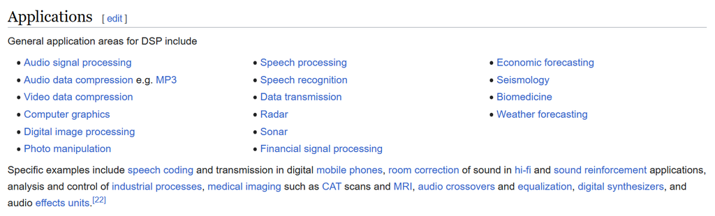

Source: https://en.wikipedia.org/wiki/Digital_signal_processing

## This lecture

01

Linear time-invariant systems

02

Discrete-time unit impulse

03

Discrete-time impulse response

04

Exercises

# LTI systems

Linear time-invariant systems

## System

**Show plot code**

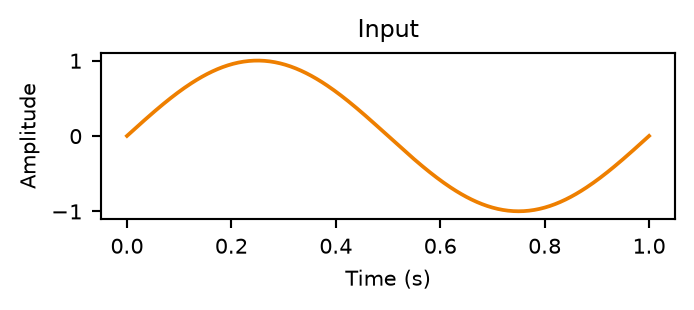

```python
samples = np.linspace(0, 1, 301)
values = np.sin(2 * np.pi * samples)
fig, ax = plt.subplots(figsize=(3.5, 1.5), layout="constrained")
ax.plot(samples, values, color=HANZE_ORANGE, linewidth=1.4)
ax.set(title='Input', xlabel='Time (s)', ylabel="Amplitude", ylim=(-1.1, 1.1))
plt.show()
plt.close(fig)
```

$x(t)$

Continuous system

$y(t)$

**Show plot code**

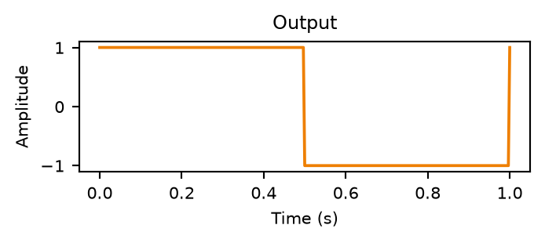

```python
samples = np.linspace(0, 1, 301)
values = np.where((samples % 1.0) < 0.5, 1.0, -1.0)
fig, ax = plt.subplots(figsize=(3.5, 1.5), layout="constrained")
ax.plot(samples, values, color=HANZE_ORANGE, linewidth=1.4)
ax.set(title='Output', xlabel='Time (s)', ylabel="Amplitude", ylim=(-1.1, 1.1))
plt.show()
plt.close(fig)
```

**Show plot code**

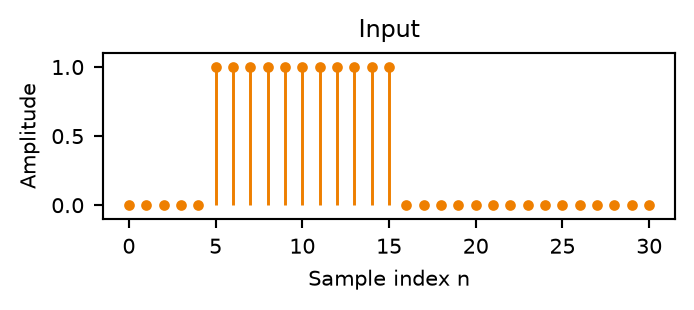

```python
samples = np.arange(0, 31)
values = ((samples >= 5) & (samples <= 15)).astype(float)
fig, ax = plt.subplots(figsize=(3.5, 1.5), layout="constrained")
markers, stems, baseline = ax.stem(samples, values, basefmt=" ", label=None)
plt.setp(markers, color=HANZE_ORANGE, markersize=3)
plt.setp(stems, color=HANZE_ORANGE, linewidth=1.1)
baseline.set_visible(False)
ax.set(title='Input', xlabel='Sample index n', ylabel="Amplitude", ylim=(-0.1, 1.1))
plt.show()
plt.close(fig)
```

$x[n]$

Discrete  
system

$y[n]$

**Show plot code**

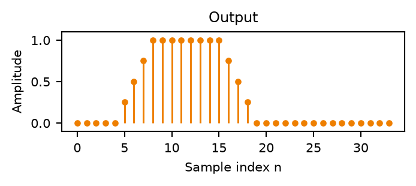

```python
samples = np.arange(0, 31)
input_indices = np.arange(31)
x = ((input_indices >= 5) & (input_indices <= 15)).astype(float)
impulse_response = np.array([0.25, 0.25, 0.25, 0.25])
values = np.convolve(x, impulse_response)
samples = np.arange(34)
fig, ax = plt.subplots(figsize=(3.5, 1.5), layout="constrained")
markers, stems, baseline = ax.stem(samples, values, basefmt=" ", label=None)
plt.setp(markers, color=HANZE_ORANGE, markersize=3)
plt.setp(stems, color=HANZE_ORANGE, linewidth=1.1)
baseline.set_visible(False)
ax.set(title='Output', xlabel='Sample index n', ylabel="Amplitude", ylim=(-0.1, 1.1))
plt.show()
plt.close(fig)
```

A system transforms an input signal into an output signal.

## Linear time-invariant system

- Linearity consists of **homogeneity** and **additivity**.
- **Shift invariance** is also called time invariance.

## Homogeneity

Both discrete systems represent the same system.

**Show plot code**

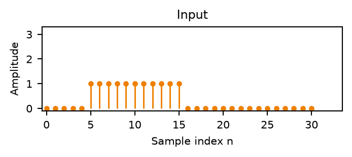

```python
samples = np.arange(31)
values = ((samples >= 5) & (samples <= 15)).astype(float)
fig, ax = plt.subplots(figsize=(3.5, 1.5), layout="constrained")
markers, stems, baseline = ax.stem(samples, values, basefmt=" ", label=None)
plt.setp(markers, color=HANZE_ORANGE, markersize=3)
plt.setp(stems, color=HANZE_ORANGE, linewidth=1.1)
baseline.set_visible(False)
ax.set(title="Input", xlabel="Sample index n", ylabel="Amplitude", ylim=(-0.1, 3.3), xlim=(-0.5, 33.5))
ax.set_xticks(np.arange(0, 31, 5))
ax.set_yticks(np.arange(0, 4, 1))
plt.show()
plt.close(fig)
```

$x[n]$

Discrete  
system

$y[n]$

**Show plot code**

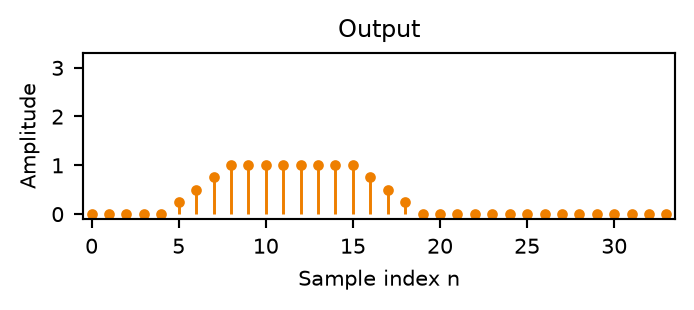

```python
input_indices = np.arange(0, 31)
x = ((input_indices >= 5) & (input_indices <= 15)).astype(float)
impulse_response = np.array([0.25, 0.25, 0.25, 0.25])
values = np.convolve(x, impulse_response)
samples = np.arange(0, 34)
fig, ax = plt.subplots(figsize=(3.5, 1.5), layout="constrained")
markers, stems, baseline = ax.stem(samples, values, basefmt=" ", label=None)
plt.setp(markers, color=HANZE_ORANGE, markersize=3)
plt.setp(stems, color=HANZE_ORANGE, linewidth=1.1)
baseline.set_visible(False)
ax.set(title="Output", xlabel="Sample index n", ylabel="Amplitude", ylim=(-0.1, 3.3), xlim=(-0.5, 33.5))
ax.set_xticks(np.arange(0, 31, 5))
ax.set_yticks(np.arange(0, 4, 1))
plt.show()
plt.close(fig)
```

**Show plot code**

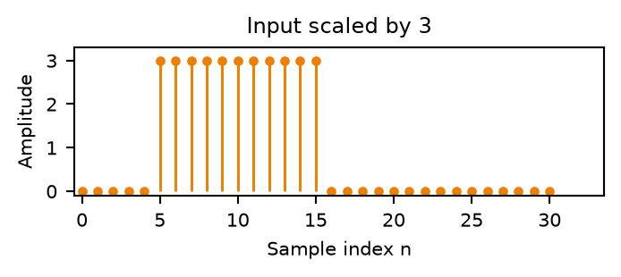

```python
samples = np.arange(31)
values = 3 * ((samples >= 5) & (samples <= 15)).astype(float)
fig, ax = plt.subplots(figsize=(3.5, 1.5), layout="constrained")
markers, stems, baseline = ax.stem(samples, values, basefmt=" ", label=None)
plt.setp(markers, color=HANZE_ORANGE, markersize=3)
plt.setp(stems, color=HANZE_ORANGE, linewidth=1.1)
baseline.set_visible(False)
ax.set(title="Input scaled by 3", xlabel="Sample index n", ylabel="Amplitude", ylim=(-0.1, 3.3), xlim=(-0.5, 33.5))
ax.set_xticks(np.arange(0, 31, 5))
ax.set_yticks(np.arange(0, 4, 1))
plt.show()
plt.close(fig)
```

$3x[n]$

Discrete  
system

$3y[n]$

**Show plot code**

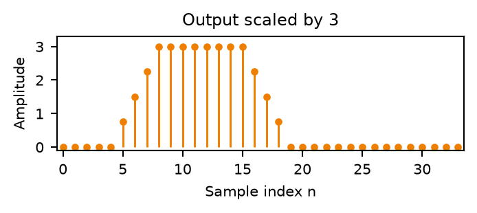

```python
input_indices = np.arange(0, 31)
x = 3 * ((input_indices >= 5) & (input_indices <= 15)).astype(float)
impulse_response = np.array([0.25, 0.25, 0.25, 0.25])
values = np.convolve(x, impulse_response)
samples = np.arange(0, 34)
fig, ax = plt.subplots(figsize=(3.5, 1.5), layout="constrained")
markers, stems, baseline = ax.stem(samples, values, basefmt=" ", label=None)
plt.setp(markers, color=HANZE_ORANGE, markersize=3)
plt.setp(stems, color=HANZE_ORANGE, linewidth=1.1)
baseline.set_visible(False)
ax.set(title="Output scaled by 3", xlabel="Sample index n", ylabel="Amplitude", ylim=(-0.1, 3.3), xlim=(-0.5, 33.5))
ax.set_xticks(np.arange(0, 31, 5))
ax.set_yticks(np.arange(0, 4, 1))
plt.show()
plt.close(fig)
```

Multiplying the input by 3 also multiplies the output by 3.

## Homogeneous? Example 1

Both discrete systems represent the same system.

Input

**Show plot code**

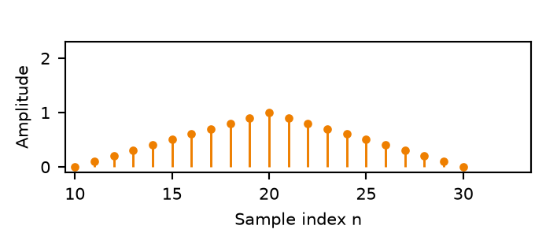

```python
samples = np.arange(31)
values = 1 * np.maximum(0, 1 - np.abs(samples - 20) / 10)
fig, ax = plt.subplots(figsize=(3.5, 1.5), layout="constrained")
markers, stems, baseline = ax.stem(samples, values, basefmt=" ", label=None)
plt.setp(markers, color=HANZE_ORANGE, markersize=3)
plt.setp(stems, color=HANZE_ORANGE, linewidth=1.1)
baseline.set_visible(False)
ax.set(title=" ", xlabel="Sample index n", ylabel="Amplitude", ylim=(-0.1, 2.3), xlim=(9.5, 33.5))
ax.set_xticks(np.arange(10, 34, 5))
ax.set_yticks(np.arange(0, 3, 1))
plt.show()
plt.close(fig)
```

$x[n]$

Discrete  
system

$y[n]$

Output

**Show plot code**

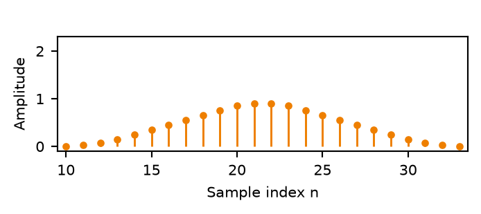

```python
input_indices = np.arange(0, 31)
x = 1 * np.maximum(0, 1 - np.abs(input_indices - 20) / 10)
impulse_response = np.array([0.25, 0.25, 0.25, 0.25])
values = np.convolve(x, impulse_response)
samples = np.arange(0, 34)
fig, ax = plt.subplots(figsize=(3.5, 1.5), layout="constrained")
markers, stems, baseline = ax.stem(samples, values, basefmt=" ", label=None)
plt.setp(markers, color=HANZE_ORANGE, markersize=3)
plt.setp(stems, color=HANZE_ORANGE, linewidth=1.1)
baseline.set_visible(False)
ax.set(title=" ", xlabel="Sample index n", ylabel="Amplitude", ylim=(-0.1, 2.3), xlim=(9.5, 33.5))
ax.set_xticks(np.arange(10, 34, 5))
ax.set_yticks(np.arange(0, 3, 1))
plt.show()
plt.close(fig)
```

Input doubled

**Show plot code**

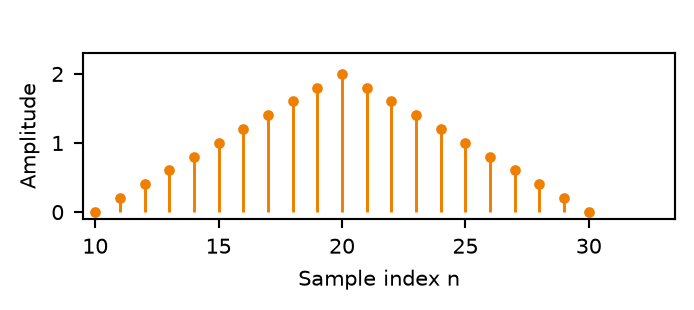

```python
samples = np.arange(31)
values = 2 * np.maximum(0, 1 - np.abs(samples - 20) / 10)
fig, ax = plt.subplots(figsize=(3.5, 1.5), layout="constrained")
markers, stems, baseline = ax.stem(samples, values, basefmt=" ", label=None)
plt.setp(markers, color=HANZE_ORANGE, markersize=3)
plt.setp(stems, color=HANZE_ORANGE, linewidth=1.1)
baseline.set_visible(False)
ax.set(title=" ", xlabel="Sample index n", ylabel="Amplitude", ylim=(-0.1, 2.3), xlim=(9.5, 33.5))
ax.set_xticks(np.arange(10, 34, 5))
ax.set_yticks(np.arange(0, 3, 1))
plt.show()
plt.close(fig)
```

$2x[n]$

Discrete  
system

$2y[n]$

Output doubled

**Show plot code**

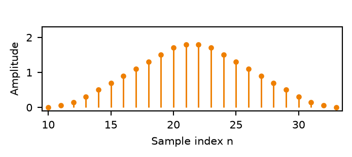

```python
input_indices = np.arange(0, 31)
x = 2 * np.maximum(0, 1 - np.abs(input_indices - 20) / 10)
impulse_response = np.array([0.25, 0.25, 0.25, 0.25])
values = np.convolve(x, impulse_response)
samples = np.arange(0, 34)
fig, ax = plt.subplots(figsize=(3.5, 1.5), layout="constrained")
markers, stems, baseline = ax.stem(samples, values, basefmt=" ", label=None)
plt.setp(markers, color=HANZE_ORANGE, markersize=3)
plt.setp(stems, color=HANZE_ORANGE, linewidth=1.1)
baseline.set_visible(False)
ax.set(title=" ", xlabel="Sample index n", ylabel="Amplitude", ylim=(-0.1, 2.3), xlim=(9.5, 33.5))
ax.set_xticks(np.arange(10, 34, 5))
ax.set_yticks(np.arange(0, 3, 1))
plt.show()
plt.close(fig)
```

Homogeneous. Doubling the input doubles the output.

## Homogeneous? Example 2

Both discrete systems represent the same system.

Input

**Show plot code**

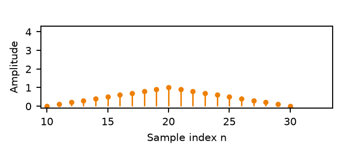

```python
samples = np.arange(31)
values = 1 * np.maximum(0, 1 - np.abs(samples - 20) / 10)
fig, ax = plt.subplots(figsize=(3.5, 1.5), layout="constrained")
markers, stems, baseline = ax.stem(samples, values, basefmt=" ", label=None)
plt.setp(markers, color=HANZE_ORANGE, markersize=3)
plt.setp(stems, color=HANZE_ORANGE, linewidth=1.1)
baseline.set_visible(False)
ax.set(title=" ", xlabel="Sample index n", ylabel="Amplitude", ylim=(-0.1, 4.3), xlim=(9.5, 33.5))
ax.set_xticks(np.arange(10, 34, 5))
ax.set_yticks(np.arange(0, 5, 1))
plt.show()
plt.close(fig)
```

$x[n]$

Discrete  
system

$y[n]$

Output

**Show plot code**

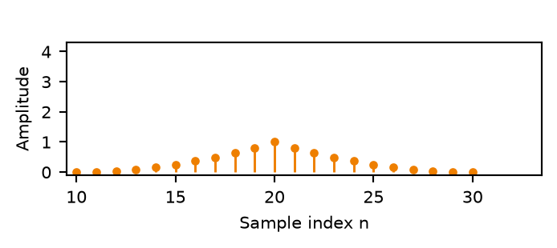

```python
samples = np.arange(31)
x = 1 * np.maximum(0, 1 - np.abs(samples - 20) / 10)
values = x ** 2
fig, ax = plt.subplots(figsize=(3.5, 1.5), layout="constrained")
markers, stems, baseline = ax.stem(samples, values, basefmt=" ", label=None)
plt.setp(markers, color=HANZE_ORANGE, markersize=3)
plt.setp(stems, color=HANZE_ORANGE, linewidth=1.1)
baseline.set_visible(False)
ax.set(title=" ", xlabel="Sample index n", ylabel="Amplitude", ylim=(-0.1, 4.3), xlim=(9.5, 33.5))
ax.set_xticks(np.arange(10, 34, 5))
ax.set_yticks(np.arange(0, 5, 1))
plt.show()
plt.close(fig)
```

Input doubled

**Show plot code**

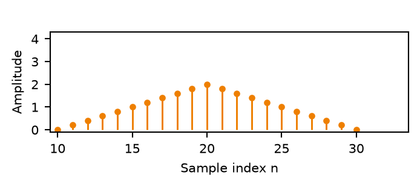

```python
samples = np.arange(31)
values = 2 * np.maximum(0, 1 - np.abs(samples - 20) / 10)
fig, ax = plt.subplots(figsize=(3.5, 1.5), layout="constrained")
markers, stems, baseline = ax.stem(samples, values, basefmt=" ", label=None)
plt.setp(markers, color=HANZE_ORANGE, markersize=3)
plt.setp(stems, color=HANZE_ORANGE, linewidth=1.1)
baseline.set_visible(False)
ax.set(title=" ", xlabel="Sample index n", ylabel="Amplitude", ylim=(-0.1, 4.3), xlim=(9.5, 33.5))
ax.set_xticks(np.arange(10, 34, 5))
ax.set_yticks(np.arange(0, 5, 1))
plt.show()
plt.close(fig)
```

$2x[n]$

Discrete  
system

$4y[n]$

Output quadrupled

**Show plot code**

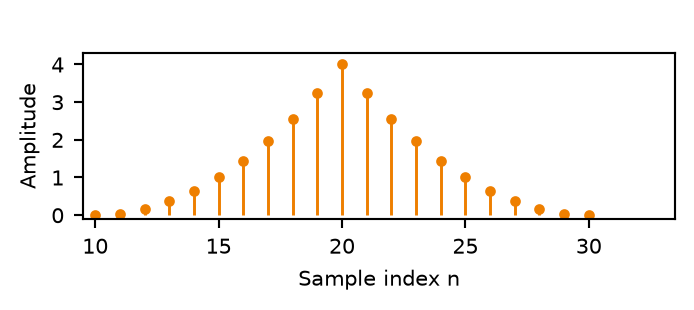

```python
samples = np.arange(31)
x = 2 * np.maximum(0, 1 - np.abs(samples - 20) / 10)
values = x ** 2
fig, ax = plt.subplots(figsize=(3.5, 1.5), layout="constrained")
markers, stems, baseline = ax.stem(samples, values, basefmt=" ", label=None)
plt.setp(markers, color=HANZE_ORANGE, markersize=3)
plt.setp(stems, color=HANZE_ORANGE, linewidth=1.1)
baseline.set_visible(False)
ax.set(title=" ", xlabel="Sample index n", ylabel="Amplitude", ylim=(-0.1, 4.3), xlim=(9.5, 33.5))
ax.set_xticks(np.arange(10, 34, 5))
ax.set_yticks(np.arange(0, 5, 1))
plt.show()
plt.close(fig)
```

Not homogeneous. Doubling the input quadruples the output, rather than doubling it.

## Additivity

All three discrete systems represent the same system.

**Show plot code**

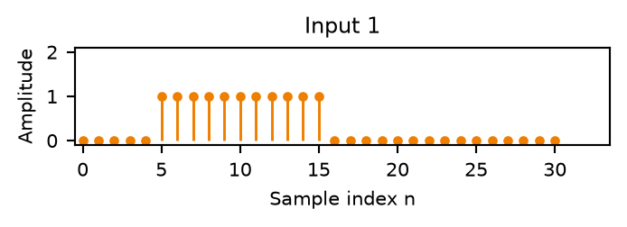

```python
samples = np.arange(31)
values = ((samples >= 5) & (samples <= 15)).astype(float)
fig, ax = plt.subplots(figsize=(3.5, 1.2), layout="constrained")
markers, stems, baseline = ax.stem(samples, values, basefmt=" ", label=None)
plt.setp(markers, color=HANZE_ORANGE, markersize=3)
plt.setp(stems, color=HANZE_ORANGE, linewidth=1.1)
baseline.set_visible(False)
ax.set(title='Input 1', xlabel='Sample index n', ylabel="Amplitude", ylim=(-0.1, 2.1), xlim=(-0.5, 33.5))
ax.set_xticks(np.arange(0, 31, 5))
ax.set_yticks([0, 1, 2])
plt.show()
plt.close(fig)
```

$x_1[n]$

Discrete  
system

$y_1[n]$

**Show plot code**

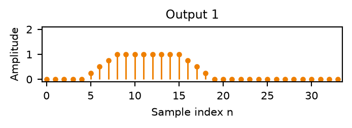

```python
samples = np.arange(34)
input_indices = np.arange(31)
x = ((input_indices >= 5) & (input_indices <= 15)).astype(float)
impulse_response = np.array([0.25, 0.25, 0.25, 0.25])
values = np.convolve(x, impulse_response)
fig, ax = plt.subplots(figsize=(3.5, 1.2), layout="constrained")
markers, stems, baseline = ax.stem(samples, values, basefmt=" ", label=None)
plt.setp(markers, color=HANZE_ORANGE, markersize=3)
plt.setp(stems, color=HANZE_ORANGE, linewidth=1.1)
baseline.set_visible(False)
ax.set(title='Output 1', xlabel='Sample index n', ylabel="Amplitude", ylim=(-0.1, 2.1), xlim=(-0.5, 33.5))
ax.set_xticks(np.arange(0, 31, 5))
ax.set_yticks([0, 1, 2])
plt.show()
plt.close(fig)
```

**Show plot code**

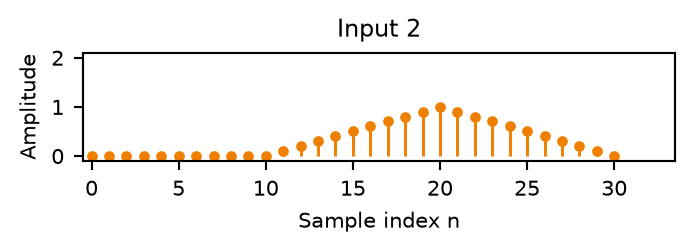

```python
samples = np.arange(31)
values = np.maximum(0, 1 - np.abs(samples - 20) / 10)
fig, ax = plt.subplots(figsize=(3.5, 1.2), layout="constrained")
markers, stems, baseline = ax.stem(samples, values, basefmt=" ", label=None)
plt.setp(markers, color=HANZE_ORANGE, markersize=3)
plt.setp(stems, color=HANZE_ORANGE, linewidth=1.1)
baseline.set_visible(False)
ax.set(title='Input 2', xlabel='Sample index n', ylabel="Amplitude", ylim=(-0.1, 2.1), xlim=(-0.5, 33.5))
ax.set_xticks(np.arange(0, 31, 5))
ax.set_yticks([0, 1, 2])
plt.show()
plt.close(fig)
```

$x_2[n]$

Discrete  
system

$y_2[n]$

**Show plot code**

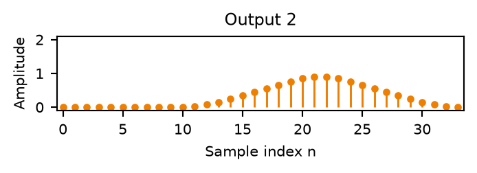

```python
samples = np.arange(34)
input_indices = np.arange(31)
x = np.maximum(0, 1 - np.abs(input_indices - 20) / 10)
impulse_response = np.array([0.25, 0.25, 0.25, 0.25])
values = np.convolve(x, impulse_response)
fig, ax = plt.subplots(figsize=(3.5, 1.2), layout="constrained")
markers, stems, baseline = ax.stem(samples, values, basefmt=" ", label=None)
plt.setp(markers, color=HANZE_ORANGE, markersize=3)
plt.setp(stems, color=HANZE_ORANGE, linewidth=1.1)
baseline.set_visible(False)
ax.set(title='Output 2', xlabel='Sample index n', ylabel="Amplitude", ylim=(-0.1, 2.1), xlim=(-0.5, 33.5))
ax.set_xticks(np.arange(0, 31, 5))
ax.set_yticks([0, 1, 2])
plt.show()
plt.close(fig)
```

**Show plot code**

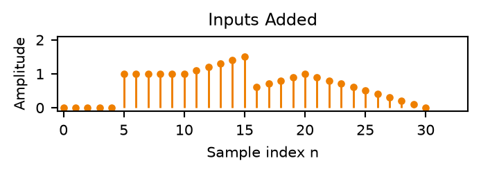

```python
samples = np.arange(31)
x1 = ((samples >= 5) & (samples <= 15)).astype(float)
x2 = np.maximum(0, 1 - np.abs(samples - 20) / 10)
values = x1 + x2
fig, ax = plt.subplots(figsize=(3.5, 1.2), layout="constrained")
markers, stems, baseline = ax.stem(samples, values, basefmt=" ", label=None)
plt.setp(markers, color=HANZE_ORANGE, markersize=3)
plt.setp(stems, color=HANZE_ORANGE, linewidth=1.1)
baseline.set_visible(False)
ax.set(title='Inputs Added', xlabel='Sample index n', ylabel="Amplitude", ylim=(-0.1, 2.1), xlim=(-0.5, 33.5))
ax.set_xticks(np.arange(0, 31, 5))
ax.set_yticks([0, 1, 2])
plt.show()
plt.close(fig)
```

$x_1[n]+x_2[n]$

Discrete  
system

$y_1[n]+y_2[n]$

**Show plot code**

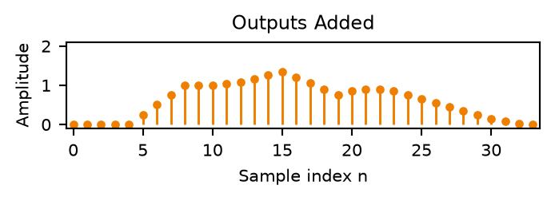

```python
samples = np.arange(34)
input_indices = np.arange(31)
x1 = ((input_indices >= 5) & (input_indices <= 15)).astype(float)
x2 = np.maximum(0, 1 - np.abs(input_indices - 20) / 10)
x = x1 + x2
impulse_response = np.array([0.25, 0.25, 0.25, 0.25])
values = np.convolve(x, impulse_response)
fig, ax = plt.subplots(figsize=(3.5, 1.2), layout="constrained")
markers, stems, baseline = ax.stem(samples, values, basefmt=" ", label=None)
plt.setp(markers, color=HANZE_ORANGE, markersize=3)
plt.setp(stems, color=HANZE_ORANGE, linewidth=1.1)
baseline.set_visible(False)
ax.set(title='Outputs Added', xlabel='Sample index n', ylabel="Amplitude", ylim=(-0.1, 2.1), xlim=(-0.5, 33.5))
ax.set_xticks(np.arange(0, 31, 5))
ax.set_yticks([0, 1, 2])
plt.show()
plt.close(fig)
```

Adding the inputs before the system gives the same result as adding the outputs afterwards.

## Additive?

All three discrete systems represent the same system.

Input 1

**Show plot code**

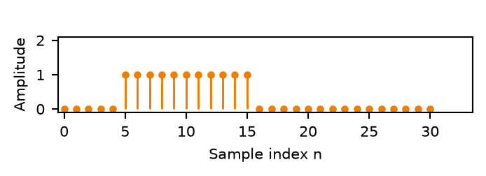

```python
samples = np.arange(31)
values = ((samples >= 5) & (samples <= 15)).astype(float)
fig, ax = plt.subplots(figsize=(3.5, 1.2), layout="constrained")
markers, stems, baseline = ax.stem(samples, values, basefmt=" ", label=None)
plt.setp(markers, color=HANZE_ORANGE, markersize=3)
plt.setp(stems, color=HANZE_ORANGE, linewidth=1.1)
baseline.set_visible(False)
ax.set(title=" ", xlabel="Sample index n", ylabel="Amplitude", ylim=(-0.1, 2.1), xlim=(-0.5, 33.5))
ax.set_xticks(np.arange(0, 31, 5))
ax.set_yticks(np.arange(0, 3, 1))
plt.show()
plt.close(fig)
```

$x_1[n]$

Discrete  
system

$y_1[n]$

Output 1

**Show plot code**

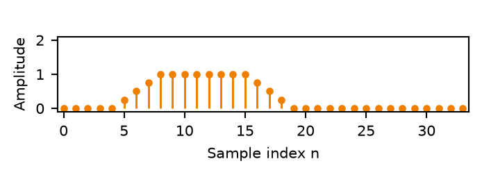

```python
input_indices = np.arange(0, 31)
x = ((input_indices >= 5) & (input_indices <= 15)).astype(float)
impulse_response = np.array([0.25, 0.25, 0.25, 0.25])
values = np.convolve(x, impulse_response)
samples = np.arange(0, 34)
fig, ax = plt.subplots(figsize=(3.5, 1.2), layout="constrained")
markers, stems, baseline = ax.stem(samples, values, basefmt=" ", label=None)
plt.setp(markers, color=HANZE_ORANGE, markersize=3)
plt.setp(stems, color=HANZE_ORANGE, linewidth=1.1)
baseline.set_visible(False)
ax.set(title=" ", xlabel="Sample index n", ylabel="Amplitude", ylim=(-0.1, 2.1), xlim=(-0.5, 33.5))
ax.set_xticks(np.arange(0, 31, 5))
ax.set_yticks(np.arange(0, 3, 1))
plt.show()
plt.close(fig)
```

Input 2

**Show plot code**

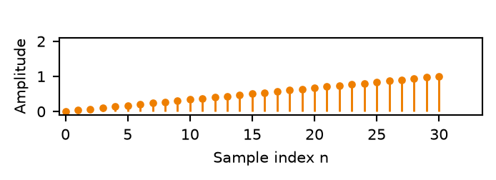

```python
samples = np.arange(31)
values = samples / 30
fig, ax = plt.subplots(figsize=(3.5, 1.2), layout="constrained")
markers, stems, baseline = ax.stem(samples, values, basefmt=" ", label=None)
plt.setp(markers, color=HANZE_ORANGE, markersize=3)
plt.setp(stems, color=HANZE_ORANGE, linewidth=1.1)
baseline.set_visible(False)
ax.set(title=" ", xlabel="Sample index n", ylabel="Amplitude", ylim=(-0.1, 2.1), xlim=(-0.5, 33.5))
ax.set_xticks(np.arange(0, 31, 5))
ax.set_yticks(np.arange(0, 3, 1))
plt.show()
plt.close(fig)
```

$x_2[n]$

Discrete  
system

$y_2[n]$

Output 2

**Show plot code**

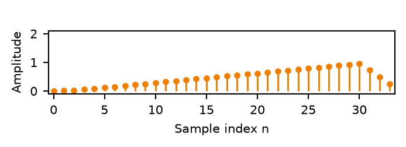

```python
input_indices = np.arange(0, 31)
x = input_indices / 30
impulse_response = np.array([0.25, 0.25, 0.25, 0.25])
values = np.convolve(x, impulse_response)
samples = np.arange(0, 34)
fig, ax = plt.subplots(figsize=(3.5, 1.2), layout="constrained")
markers, stems, baseline = ax.stem(samples, values, basefmt=" ", label=None)
plt.setp(markers, color=HANZE_ORANGE, markersize=3)
plt.setp(stems, color=HANZE_ORANGE, linewidth=1.1)
baseline.set_visible(False)
ax.set(title=" ", xlabel="Sample index n", ylabel="Amplitude", ylim=(-0.1, 2.1), xlim=(-0.5, 33.5))
ax.set_xticks(np.arange(0, 31, 5))
ax.set_yticks(np.arange(0, 3, 1))
plt.show()
plt.close(fig)
```

Inputs added

**Show plot code**

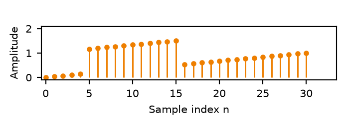

```python
samples = np.arange(31)
values = ((samples >= 5) & (samples <= 15)).astype(float) + samples / 30
fig, ax = plt.subplots(figsize=(3.5, 1.2), layout="constrained")
markers, stems, baseline = ax.stem(samples, values, basefmt=" ", label=None)
plt.setp(markers, color=HANZE_ORANGE, markersize=3)
plt.setp(stems, color=HANZE_ORANGE, linewidth=1.1)
baseline.set_visible(False)
ax.set(title=" ", xlabel="Sample index n", ylabel="Amplitude", ylim=(-0.1, 2.1), xlim=(-0.5, 33.5))
ax.set_xticks(np.arange(0, 31, 5))
ax.set_yticks(np.arange(0, 3, 1))
plt.show()
plt.close(fig)
```

$x_1[n]+x_2[n]$

Discrete  
system

$y_1[n]+y_2[n]$

Output for added inputs

**Show plot code**

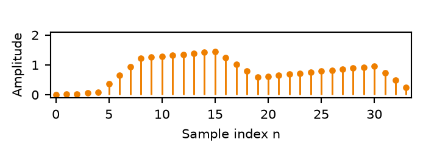

```python
input_indices = np.arange(0, 31)
x = ((input_indices >= 5) & (input_indices <= 15)).astype(float) + input_indices / 30
impulse_response = np.array([0.25, 0.25, 0.25, 0.25])
values = np.convolve(x, impulse_response)
samples = np.arange(0, 34)
fig, ax = plt.subplots(figsize=(3.5, 1.2), layout="constrained")
markers, stems, baseline = ax.stem(samples, values, basefmt=" ", label=None)
plt.setp(markers, color=HANZE_ORANGE, markersize=3)
plt.setp(stems, color=HANZE_ORANGE, linewidth=1.1)
baseline.set_visible(False)
ax.set(title=" ", xlabel="Sample index n", ylabel="Amplitude", ylim=(-0.1, 2.1), xlim=(-0.5, 33.5))
ax.set_xticks(np.arange(0, 31, 5))
ax.set_yticks(np.arange(0, 3, 1))
plt.show()
plt.close(fig)
```

Additive. The output for the added inputs equals the sum of the two separate outputs.